# Training Better Listeners in a Second Language

Patricia Amillos

2023-02-08

## Custom functions

Throughout my experiments, I had to download CSV files with the same format multiple times and wrangle to get the relevant information. Instead of writing out the code repeatedly, I created a set of custom functions that would do all the processing for me so I can get to the analysis quicker. I share examples of these functions here.

### Who is participating in my experiments?

I have a csv file of survey data about the personal characteristics of my participants in long format. The data frame looks like this:

```r
participants <- read.csv("screening.csv")
head(participants)
```

```
##   Event.Index UTC.Timestamp            UTC.Date Local.Timestamp Local.Timezone
## 1           1  1.610794e+12 16/01/2021 10:40:16    1.610794e+12              1
## 2           2  1.610794e+12 16/01/2021 10:40:50    1.610794e+12              1
## 3           3  1.610794e+12 16/01/2021 10:40:50    1.610794e+12              1
## 4           4  1.610794e+12 16/01/2021 10:40:50    1.610794e+12              1
## 5           5  1.610794e+12 16/01/2021 10:40:50    1.610794e+12              1
## 6           6  1.610794e+12 16/01/2021 10:40:50    1.610794e+12              1
##            Local.Date Experiment.ID Experiment.Version      Tree.Node.Key
## 1 16/01/2021 11:40:20         30398                 14 questionnaire-vz8s
## 2 16/01/2021 11:40:54         30398                 14 questionnaire-vz8s
## 3 16/01/2021 11:40:54         30398                 14 questionnaire-vz8s
## 4 16/01/2021 11:40:54         30398                 14 questionnaire-vz8s
## 5 16/01/2021 11:40:54         30398                 14 questionnaire-vz8s
## 6 16/01/2021 11:40:54         30398                 14 questionnaire-vz8s
##   Repeat.Key Schedule.ID Participant.Public.ID Participant.Private.ID
```

[output cut: 76 more lines]

### Function 1: Filtering the data

Purpose: I need to save the same set of columns that contain the subject identifier, question, and responses for participant CSV files. Not all rows contain responses. I want to quickly extract these.

Here is an example of how the responses are recorded.

```r
head(participants %>% select ('Question.Key', 'Response'))
```

```
##           Question.Key Response
## 1  BEGIN QUESTIONNAIRE
## 2                  age       51
## 3           response-1 Männlich
## 4 response-1-quantised        2
## 5           response-2     Nein
## 6 response-2-quantised        2
```

The keep questions function applies the necessary filters so we only retain the required part of the data frame.

```r
keep_questions <- function (a) {
  a %>%
    select("Participant.Public.ID", "Question.Key", "Response") %>%
    #select columns for subject identifier, rows that contain the questions, and their responses
    set_names("ID", "question", "response") %>% #replace column names for readability and ease of referencing
    filter(question != "BEGIN QUESTIONNAIRE" & question != "END QUESTIONNAIRE") #these rows contain no responses
}
```

By running the keep_questions function, we get a tidy data frame without pasting the same 4 lines of code repeatedly.

```r
participants_clean <- keep_questions(participants)
head(participants_clean)
```

```
##      ID             question response
## 1 b6720                  age       51
## 2 b6720           response-1 Männlich
## 3 b6720 response-1-quantised        2
## 4 b6720           response-2     Nein
## 5 b6720 response-2-quantised        2
## 6 b6720           response-4  Deutsch
```

### Function 2: Pivoting the data

The participants_clean data set is in long format, but for the analysis I need the rows under the questions column to be column names. I wrote the “spread_df” function to pivot the data into the desired format.

```r
spread_df <- function (a) {
  a %>% spread(question, response) %>% #converts the rows into a wide format with questions as column names
    select("ID", "age", "response-1", "response-2", "response-3", "response-4") %>% #rows containing responses
    set_names("ID", "age", "sex", "DLD", "hindi_exposure", "languages_spoken") %>% #renaming columns based on info asked
    mutate_at("age", as.numeric) %>% # age is a numerical variable
    mutate_at(c("ID", "sex", "DLD", "hindi_exposure", "languages_spoken"), as.factor) %>% #convert categorical data to factors
    mutate(languages_spoken = tolower(languages_spoken)) %>% # participants used different cases in the open text box
    arrange(age) # sort the participants by ascending order to get idea of age range
}
```

Because we sorted the data frame by age, we can quickly see that some participants didn’t provide their age! That will be an important thing to handle in the next step.

```r
participants_clean <- spread_df(participants_clean)
head(participants_clean)
```

```
##      ID age      sex  DLD hindi_exposure languages_spoken
## 1 b6688   0 Weiblich Nein           Nein          deutsch
## 2 b6758   0 Weiblich Nein           Nein          deutsch
## 3 ksw01   0 Männlich Nein           Nein          deutsch
## 4 b6660  49 Weiblich Nein           Nein          deutsch
## 5 b6765  50 Weiblich Nein           Nein          deutsch
## 6 b6766  50 Männlich Nein           Nein          deutsch
```

## Plotting

One of the plots I made for this experiment was a beeswarm plot superimposed on a bar plot. The length of the bars represented the average performance of the group while the points in the beeswarm showed the average performance of participants.

ggplot allows building plots step by step which makes for an interesting combination of visuals!

```r
# Group at the individual level to display multiple points in a beeswarm
id_beeswarm <- id %>%
  group_by(ID, minimalpair) %>%
  summarize(proportion_correct = mean(accuracy), std = sd(accuracy))
```

[output not shown]

```
## No summary function supplied, defaulting to `mean_se()`
```

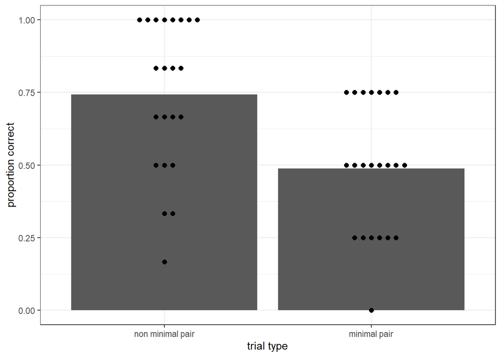

```r
# Combine the two into one plot
(ggplot(id_beeswarm, aes(x=as.factor(minimalpair), y=proportion_correct)) +
  geom_bar(stat = "summary", fun.y = "mean") + # mean as a summary function otherwise bars will show a count
  ylim(0,1) +
  ylab("proportion correct") +
  xlab("trial type") +
  geom_beeswarm(cex=2, size = 2) +
  theme_bw())
```